# Così fan tutte

### Zweiter Akt

Despina bedeutet Fiordiligi und Dorabella, dass überhaupt nichts dabei ist, den offenbar so unsterblich in sie verliebten Fremden nachzugeben. In der Tat finden die beiden so langsam Gefallen daran – dabei bevorzugt Fiordiligi Ferrando und Dorabella Guglielmo, also den jeweils Anderen ihrer ursprünglichen Verbindung.  
Die beiden jungen Männer bringen ihren zum Schein Angebeteten ein Ständchen. Alfonso ermutigt die Frauen erneut, sich nicht zu verschlossen zu zeigen, Despina unterstützt ihn dabei.  
Guglielmo gewinnt die Zuneigung Dorabellas, nach kurzer Zeit schon verschenken sie ihre Herzen. Fiordiligi aber weist Ferrando ab – sie könne ihrem Verlobten nicht untreu werden, ihre Gedanken sind bei ihm.  
Ferrando und Guglielmo tauschen ihre Erfahrungen aus. Während Fiordiligis Treue zu Guglielmos Freude unerschüttert scheint, muss Ferrando erkennen, dass es Dorabella offenbar nicht sonderlich ernst ist. Guglielmo sieht darin den wahren Charakter der Frauen, Ferrando fürchtet hingegen den Spott Alfonsos, fühlt sich aber immer noch zu Dorabella hingezogen.  
Alfonso ist dabei, das Spiel weiterzutreiben; immerhin müssten Guglielmo und Ferrando bis morgen noch seinen Anweisungen folgen.  
Dorabella bekennt, in den Fremden verliebt zu sein, den sie sich auserwählt hatte. Fiordiligi offenbart, dass auch sie verliebt sei, und zwar nicht nur in ihren Verlobten. Da die Chance, dass ihre Verlobten zurückkehren, wohl nicht allzu groß ist, wäre es sicher besser, sich mit den beiden Fremden zu verbinden, zumal sie ihre Sympathien gewonnen haben. Dorabella versucht, ihre Schwester zu dieser Entscheidung zu überreden.  
Fiordiligi aber zögert – vielmehr will sie in Männerkleidern zu ihrem Verlobten Guglielmo eilen, um ihre vermeintlich verlorene Ehre wiederherzustellen. Ferrando aber bestürmt sie erneut mit Liebesbeteuerungen. Schließlich kann Fiordiligi nicht länger widerstehen.  
Guglielmo ist außer sich – auch er musste nun die Untreue seiner Verlobten erkennen. Die beiden jungen Männer sind gewillt, aufgrund dieser Erfahrungen ihre vormaligen Partner zu verlassen. Alfonso aber verspricht, alles wieder einzurenken. Er entschuldigt das Handeln der Frauen, mündend in dem Spruch: „Così fan tutte – So machen sie es alle“.  
Despina berichtet, dass zur Hochzeit der beiden neuen, „falschen“ Paare alles vorbereitet ist. Festlich werden sie empfangen, die als Notar verkleidete Despina verliest den Ehekontrakt. In dem Moment, als die vier Brautleute unterschreiben wollen, kündigt sich die Rückkehr der beiden „echten“ Verlobten an. Fiordiligi und Dorabella sind in Angst, was nun geschehen werde. Guglielmo und Ferrando, nun wieder in ihrer eigentlichen Identität und Gestalt, begrüßen ihre Verlobten nach nur einem Tag der Abwesenheit. Diese sind von der Situation überfordert. Despina gibt zu, sich als Notar verkleidet und in einer Maskerade mitgespielt zu haben. Als Guglielmo und Ferrando die Eheverträge entdecken und den beiden Frauen Verrat vorwerfen, müssen sie ihre Untreue gestehen – eine strenge Strafe wäre nur gerecht. Ihre Verlobten geben sich daraufhin als jene Fremden zu erkennen, die einen Tag lang ihnen nachgestellt und sie für sich gewonnen hatten. Alfonso versucht, die Paare wieder zu versöhnen – alle Täuschungen und Ent-Täuschungen seien geschehen, damit am Ende alle klüger sind.

> Anhaltend donnernden Applaus gab es am Sonntagabend für Solisten, Staatsopernchor und Staatskapelle unter Barenboim sowie Huguet und seinem Team.

> dpa-Basisdienst, 3. Oktober 2021

> Huguet platziert das Geschehen französisch-stilsicher und stimmig in eine Umgebung, die sowohl im heute als in der Blumenkinder-Welt der späten 60er und 70er Jahren angesiedelt sein könnte. Dabei begreift er [Huguet] „Così“ als das, was es nach der Intention von Mozart und da Ponte wohl auch sein soll: als Komödie.

> Der Tagesspiegel, 5. Oktober 2021

> Und „Così fan tutte“, das man immer für tendenziell frauenfeindlich gehalten hat, schimmert plötzlich in einem freundlicherem, modernen Licht: Ist nicht die freie Liebe das Problem, sondern das strikte, veraltete, im Grunde unmenschliches Verständnis von Treue?

> Der Tagesspiegel, 5. Oktober 2021

> Daniel Barenboim lässt seine Staatskapelle all jene zärtliche Berauschtheit hervorzaubern, die in diesem Versteckspiel der Gefühle aufzufinden sind.

> Berliner Morgenpost, 5. Oktober 2021

> Stimmlich sind alle strak, überragend ist Federica Lombardi als Fiordiligi. Daniel Barenboim agiert gewohnt exzellent im Orchestergraben.

> B.Z., 5. Oktober 2021

[Programmbuch Download](https://www.staatsoper-berlin.de/downloads-b/de/produktion/7541/programmbuch/61f7b86b4b87bc71b8d7bee61093ab76/Cosi_fan_tutte_ProgHeft_03102021+.pdf)

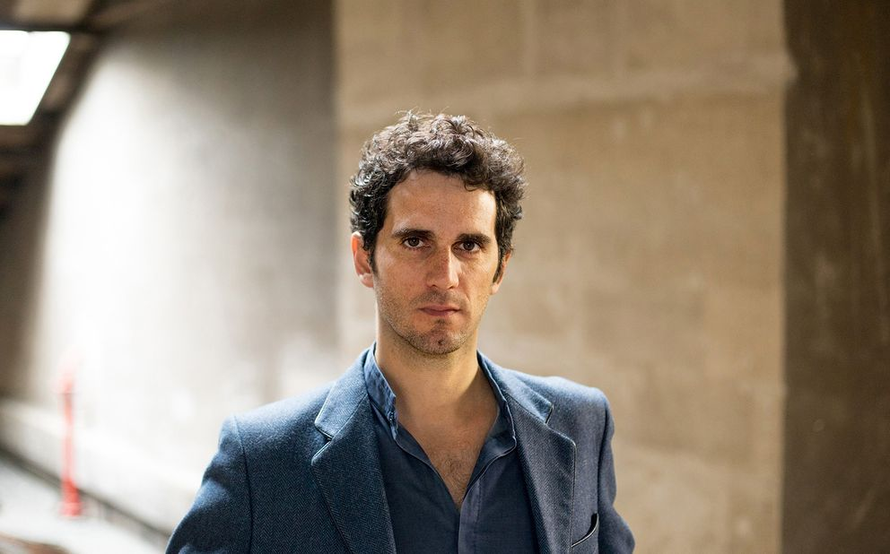

### [Eine Trilogie unserer Zeit](https://blog.staatsoper-berlin.de/mozarts-da-ponte-opern-eine-trilogie-unserer-zeit/)

- Regisseur Vincent Huguet über seine Inszenierung von Mozarts Da-Ponte-Opern.

[interactive chart not shown]